# Week 3 Discussion

# Market Basket Analysis Using Store Sales Data (Tasks)

### 1. Examine and demonstrate the data structure using your own preferred ways in excel or R

### 2. Import the dataset into R as a transaction format dataset

```r
library(arules)
```

```r
library(arulesViz)
# read in data to view in original form, THEN put into a transaction format
transaction.df <- read.csv("C:/Users/bae96639/Desktop/Uploads/transactions1.csv", sep=",")

head(transaction.df)
```

```
##   Quantity Transaction        Product
## 1        1       12359      Candy Bar
## 2        2       12362  Pain Reliever
## 3        2       12362  Pain Reliever
## 4        1       12365     Toothpaste
## 5        2       12371            Bow
## 6        1       12380 Greeting Cards
```

```r
transaction <- read.transactions("C:/Users/bae96639/Desktop/Uploads/transactions1.csv",format = "single",  header = TRUE, sep = ",", cols = c("Transaction","Product"))

summary(transaction)
```

```
## transactions as itemMatrix in sparse format with
##  200000 rows (elements/itemsets/transactions) and
##  17 columns (items) and a density of 0.08535676
##
## most frequent items:
##       Magazine      Candy Bar     Toothpaste Greeting Cards           Pens
##          48261          34201          32085          29377          28715
##        (Other)
##         117574
##
## element (itemset/transaction) length distribution:
## sizes
##      1      2      3      4      5      6      7      8      9     10     11
## 143599  35034  13833   4702   1684    641    260    134     69     28     13
##     12     13
##      2      1
##
##    Min. 1st Qu.  Median    Mean 3rd Qu.    Max.
##   1.000   1.000   1.000   1.451   2.000  13.000
##
## includes extended item information - examples:
##      labels
## 1       Bow
## 2 Candy Bar
## 3 Deodorant
##
## includes extended transaction information - examples:
##   transactionID
## 1       1000004
## 2       1000007
## 3        100001
```

### 3. Check some basic relationships of some variables (crossTable for example)

```r
table <- crossTable(transaction)
table
```

```
##                    Bow Candy Bar Deodorant Greeting Cards Magazine Markers
## Bow              10929       566        33            468     1447      35
## Candy Bar          566     34201        50           8732     8107     120
## Deodorant           33        50      1084             46      123       5
## Greeting Cards     468      8732        46          29377     7267      83
## Magazine          1447      8107       123           7267    48261     310
## Markers             35       120         5             83      310    1614
## Pain Reliever       44       177        20            151      364       9
## Pencils            216      6603        14           5848     6326      74
## Pens               439      2453        13           1670     4230      84
## Perfume            907      1457        84           1092     3438      38
## Photo Processing   474      1310        25           1232     3291      43
## Prescription Med   267       246         9            183      548      37
## Shampoo            518       489        14            429     1334      17
## Soap               344       422         9            259     1074      29
## Toothbrush        2268       898        34            669     2635      26
## Toothpaste         813      7956       135           6416     6333     176
## Wrapping Paper     759       688        15            543     1309      93
##                  Pain Reliever Pencils  Pens Perfume Photo Processing
## Bow                         44     216   439     907              474
## Candy Bar                  177    6603  2453    1457             1310
## Deodorant                   20      14    13      84               25
## Greeting Cards             151    5848  1670    1092             1232
## Magazine                   364    6326  4230    3438             3291
## Markers                      9      74    84      38               43
## Pain Reliever             5340     110   126     131              112
## Pencils                    110   26985  1420     660              652
## Pens                       126    1420 28715    1090              780
## Perfume                    131     660  1090   17992              716
## Photo Processing           112     652   780     716            11696
## Prescription Med            18     121   179     146              174
## Shampoo                     79     211   441     783              351
## Soap                        26     263   847     336              157
## Toothbrush                  85     407  1204    4364              560
## Toothpaste                 168    4912  2063    1412             1323
## Wrapping Paper              48     362   538     432              410
##                  Prescription Med Shampoo Soap Toothbrush Toothpaste
## Bow                           267     518  344       2268        813
## Candy Bar                     246     489  422        898       7956
## Deodorant                       9      14    9         34        135
```

[output cut: 17 more lines]

```
## Deodorant                    15
## Greeting Cards              543
## Magazine                   1309
## Markers                      93
## Pain Reliever                48
## Pencils                     362
## Pens                        538
## Perfume                     432
## Photo Processing            410
## Prescription Med           1215
## Shampoo                     348
## Soap                        410
## Toothbrush                  628
## Toothpaste                 1218
## Wrapping Paper            10198
```

I’m interested in some of the relationships displayed here. I wouldn’t have thought that magazines and toothpaste would have as strong as a relationship. The only issue I have with the crossTable function is that this is point in time data, and I wouldn’t want to assume that correlations I see here are telling of actual relationships between items overall.

```r
inspect(transaction[1:10])
```

```
##      items                       transactionID
## [1]  {Pencils}                   1000004
## [2]  {Soap}                      1000007
## [3]  {Candy Bar}                 100001
## [4]  {Pens}                      1000010
## [5]  {Greeting Cards}            1000016
## [6]  {Greeting Cards,Toothpaste} 1000022
## [7]  {Toothpaste}                1000025
## [8]  {Pencils,Toothpaste}        1000031
## [9]  {Greeting Cards}            1000034
## [10] {Greeting Cards}            1000037
```

### 4. Check item frequency and display them (any implications?)

```r
summary(itemFrequency(transaction))
```

```
##    Min. 1st Qu.  Median    Mean 3rd Qu.    Max.
## 0.00542 0.03380 0.05848 0.08536 0.14358 0.24130
```

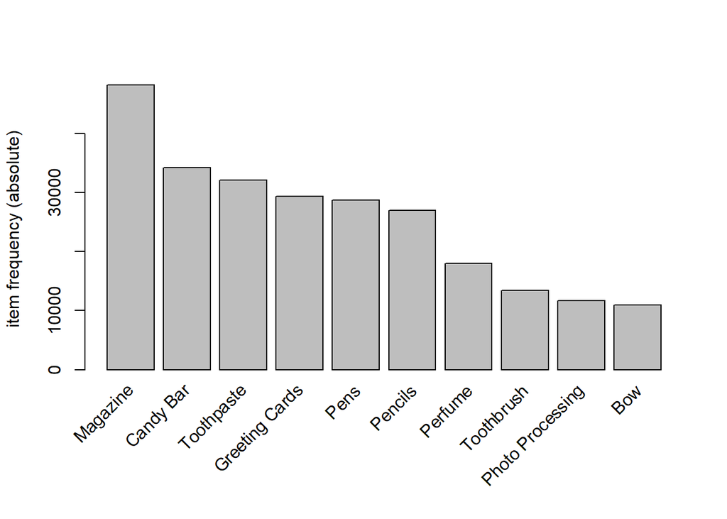

```r
itemFrequencyPlot(transaction,topN=10,type="absolute")
```

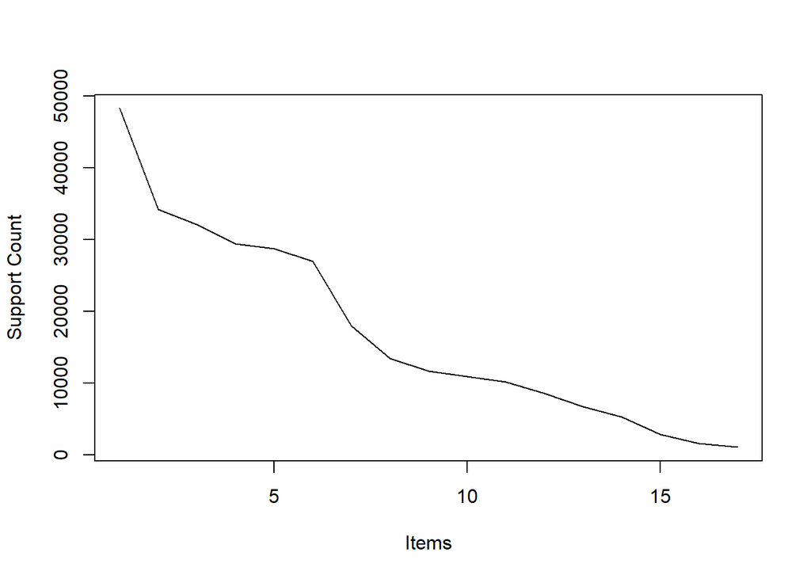

```r
plot(sort(itemFrequency(transaction, type="absolute"), decreasing=TRUE),
     xlab = "Items", ylab="Support Count", type="l")
```

This seems to be a better way to look at item popularity and distribution. This seems to imply that attempts at mining the data will focus on the relationships magazines have with the rest of the items offered. Just as well, one area of focus could be the less popular items and how to increase their profitability, or deciding to pull from the shelves entirely.

### 5. Use “apriori()” to build model and analyze the data (experiment “supp=” and “conf=”)

```r
#parameters provided in weekly practice
mbasket <- apriori(transaction, parameter=list(supp=0.01, conf=0.3, target="rules"))
```

```
## Apriori
##
## Parameter specification:
##  confidence minval smax arem  aval originalSupport maxtime support minlen
##         0.3    0.1    1 none FALSE            TRUE       5    0.01      1
##  maxlen target   ext
##      10  rules FALSE
##
## Algorithmic control:
##  filter tree heap memopt load sort verbose
##     0.1 TRUE TRUE  FALSE TRUE    2    TRUE
##
## Absolute minimum support count: 2000
##
## set item appearances ...[0 item(s)] done [0.00s].
## set transactions ...[17 item(s), 200000 transaction(s)] done [0.03s].
## sorting and recoding items ... [15 item(s)] done [0.00s].
## creating transaction tree ... done [0.06s].
## checking subsets of size 1 2 3 4 done [0.00s].
## writing ... [20 rule(s)] done [0.00s].
## creating S4 object  ... done [0.02s].
```

There are 15 item types accounted for and only 20 rules, which isn’t bad. I’ll try altering both parameters to see how this affects my rule numbers

```r
mbasket2 <- apriori(transaction, parameter=list(supp=0.01, conf=0.5, target="rules"))
```

```
## Apriori
##
## Parameter specification:
##  confidence minval smax arem  aval originalSupport maxtime support minlen
##         0.5    0.1    1 none FALSE            TRUE       5    0.01      1
##  maxlen target   ext
##      10  rules FALSE
##
## Algorithmic control:
##  filter tree heap memopt load sort verbose
##     0.1 TRUE TRUE  FALSE TRUE    2    TRUE
##
## Absolute minimum support count: 2000
##
## set item appearances ...[0 item(s)] done [0.00s].
## set transactions ...[17 item(s), 200000 transaction(s)] done [0.02s].
## sorting and recoding items ... [15 item(s)] done [0.00s].
## creating transaction tree ... done [0.07s].
## checking subsets of size 1 2 3 4 done [0.00s].
## writing ... [0 rule(s)] done [0.00s].
## creating S4 object  ... done [0.01s].
```

Adjusting for a higher confidence parameter wasn’t helpful since I didn’t generate any rules

```r
mbasket3 <- apriori(transaction, parameter=list(supp=0.03, conf=0.3, target="rules"))
```

```
## Apriori
##
## Parameter specification:
##  confidence minval smax arem  aval originalSupport maxtime support minlen
##         0.3    0.1    1 none FALSE            TRUE       5    0.03      1
##  maxlen target   ext
##      10  rules FALSE
##
## Algorithmic control:
##  filter tree heap memopt load sort verbose
##     0.1 TRUE TRUE  FALSE TRUE    2    TRUE
##
## Absolute minimum support count: 6000
##
## set item appearances ...[0 item(s)] done [0.00s].
## set transactions ...[17 item(s), 200000 transaction(s)] done [0.03s].
## sorting and recoding items ... [13 item(s)] done [0.00s].
## creating transaction tree ... done [0.06s].
## checking subsets of size 1 2 3 done [0.00s].
## writing ... [0 rule(s)] done [0.00s].
## creating S4 object  ... done [0.01s].
```

Adjusting for a higher support was also unhelpful; not only did I not generate any rules, it also captured less itemse

### 6. Check the resulted rules regarding “lift” (what does this mean? How does that help marketing people? Any insights?)

```r
inspect(subset(mbasket, lift > 3))
```

```
##     lhs             rhs       support confidence lift    count
## [1] {Toothbrush} => {Perfume} 0.02182 0.3239792  3.60137 4364
```

Lift is the ratio of the support of the antecedent co-occurring with the consequent of any transactional relationship being explored, which is then divided by the probability that both occur if they are both independent. A lift greater than 1 suggests that the purchase of the antecedent increases the chance of a purchase of the consequent.

This value would be extremely beneficial to explore in marketing, because it exposes the very relationship being sought after with this type of analysis. Here a lift greater than 3 was explored, and in return we see that the purchase of a toothbrush heavily implies the purchase of perfume. Since anything greater than just 1 suggests a relationship to be explored, I’ll try that as well

```r
inspect(subset(mbasket, lift > 1))
```

```
##      lhs                            rhs              support  confidence
## [1]  {Toothbrush}                => {Perfume}        0.021820 0.3239792
## [2]  {Greeting Cards,Pencils}    => {Magazine}       0.010955 0.3746580
## [3]  {Magazine,Pencils}          => {Greeting Cards} 0.010955 0.3463484
## [4]  {Greeting Cards,Magazine}   => {Pencils}        0.010955 0.3014999
## [5]  {Pencils,Toothpaste}        => {Candy Bar}      0.011390 0.4637622
## [6]  {Candy Bar,Pencils}         => {Toothpaste}     0.011390 0.3449947
## [7]  {Candy Bar,Pencils}         => {Magazine}       0.012005 0.3636226
## [8]  {Magazine,Pencils}          => {Candy Bar}      0.012005 0.3795447
## [9]  {Greeting Cards,Toothpaste} => {Candy Bar}      0.013175 0.4106920
## [10] {Candy Bar,Greeting Cards}  => {Toothpaste}     0.013175 0.3017636
## [11] {Candy Bar,Toothpaste}      => {Greeting Cards} 0.013175 0.3311966
## [12] {Greeting Cards,Toothpaste} => {Magazine}       0.011945 0.3723504
## [13] {Greeting Cards,Magazine}   => {Toothpaste}     0.011945 0.3287464
## [14] {Magazine,Toothpaste}       => {Greeting Cards} 0.011945 0.3772304
```

[output cut: 27 more lines]

This includes more relationships of value that can be explored further

### 7. Pick some specific product items and check it as the “rhs” (right-hand side product) and “lhs” (left-hand side product) and find what products are closely associated with the product items that you choose. (Try “minlen=” and “maxlen=”, what are they?)

```r
lhs_rules_bow <- apriori (data=transaction, parameter=list (supp=0.001,conf = 0.15,minlen=2), appearance = list(default="rhs",lhs="Bow"), control = list (verbose=F))

lhs_rules_bow <- sort (lhs_rules_bow, by="confidence", decreasing=TRUE)

inspect(head(lhs_rules_bow))
```

```
##     lhs      rhs          support confidence lift     count
## [1] {Bow} => {Toothbrush} 0.01134 0.2075213  3.081236 2268
```

I chose to inspect bows since they seem to be less popular of a purchase when looking at item frequency. So far, I see there’s a high lift of a purchase of a toothbrush if a bow is purchased. I’m curious if this works the other way around

```r
lhs_rules_toothbrush <- apriori (data=transaction, parameter=list (supp=0.001,conf = 0.15,minlen=2), appearance = list(default="rhs",lhs="Toothbrush"), control = list (verbose=F))

lhs_rules_toothbrush <- sort (lhs_rules_toothbrush, by="lift", decreasing=TRUE)

inspect(head(lhs_rules_toothbrush))
```

```
##     lhs             rhs        support  confidence lift      count
## [1] {Toothbrush} => {Perfume}  0.021820 0.3239792  3.6013696 4364
## [2] {Toothbrush} => {Bow}      0.011340 0.1683742  3.0812364 2268
## [3] {Toothbrush} => {Magazine} 0.013175 0.1956199  0.8106749 2635
```

Since toothbrushes are a more popular item, I would draw more focus on increasing toothbrush sales since it also has high lift with bows as well as perfume.